# Classification of the Rate of Return to Homelessness in the Travis County 2017-2021.

### Fitting the Model

```r
# Define a cutoff for the binary outcome of rate of returns
cutoff <- 0.2221  # This is just an example threshold

high_risk_values <- ifelse(returns$`Rate` > cutoff, 1, 0)
#add high risk values to returns
returns <- returns |>
  mutate(HighRisk = as.factor(high_risk_values))

# Now, ensure that other predictor variables are also factors
returns |>
  mutate(PriorHousing = as.factor(PriorHousing),
         SpecificDemographic= as.factor(`Specific Demographic`),
         Fiscal.Year = as.factor(`Fiscal Year`))
```

```
## # A tibble: 467 × 13
##    `Demographic Category` `Specific Demographic`  `Fiscal Year` `SO/ES/TH/SH/PH`
##    <chr>                  <chr>                           <dbl> <chr>
##  1 Race                   American Indian or Ala…          2017 SO
##  2 Race                   Asian                            2017 SO
##  3 Race                   Black or African Ameri…          2017 SO
##  4 Race                   Native Hawaiian or Oth…          2017 SO
##  5 Race                   White                            2017 SO
##  6 Ethnicity              Hispanic/Latino                  2017 SO
##  7 Ethnicity              Non-Hispanic/Non-Latino          2017 SO
##  8 Gender                 Female                           2017 SO
##  9 Gender                 Male                             2017 SO
## 10 Gender                 Trans Female                     2017 SO
## # ℹ 457 more rows
## # ℹ 9 more variables: Numerator <dbl>, Denominator <dbl>, Rate <dbl>,
## #   `Fiscal Year Start Date` <chr>, `Fiscal Year End Date` <chr>,
## #   PriorHousing <fct>, HighRisk <fct>, SpecificDemographic <fct>,
## #   Fiscal.Year <fct>
```

```r
# Perform the logistic regression
model <- glm(HighRisk ~ PriorHousing +`Specific Demographic`+ `Fiscal Year`,
             data = returns, family = binomial())
summary(model)
```

```
##
## Call:
## glm(formula = HighRisk ~ PriorHousing + `Specific Demographic` +
##     `Fiscal Year`, family = binomial(), data = returns)
##
## Coefficients:
##                                                                   Estimate
## (Intercept)                                                     -359.17451
## PriorHousingPermanent Housing                                     -2.20251
## PriorHousingSafe Haven                                            -1.04734
## PriorHousingStreet Outreach                                        0.33831
## PriorHousingTransitional Housing                                  -2.58568
## `Specific Demographic`Adult 25-61                                  0.66772
## `Specific Demographic`Adult 62+                                    1.11029
## `Specific Demographic`American Indian or Alaskan Native           -0.42847
## `Specific Demographic`Asian                                       -1.91150
## `Specific Demographic`Black or African American                    0.43721
## `Specific Demographic`Children                                   -17.43605
## `Specific Demographic`Female                                      -0.99330
## `Specific Demographic`Gender Non-Conforming                      -17.39585
## `Specific Demographic`Hispanic/Latino                             -0.34099
## `Specific Demographic`Male                                         0.66772
## `Specific Demographic`Native Hawaiian or Other Pacific Islander   -1.89631
## `Specific Demographic`No                                          -0.28328
## `Specific Demographic`No Single Gender                           -17.79979
## `Specific Demographic`Non-Hispanic/Non-Latino                      0.98775
## `Specific Demographic`Trans Female                                -0.45080
##                                                                 Std. Error
## (Intercept)                                                      188.11658
## PriorHousingPermanent Housing                                      0.43208
## PriorHousingSafe Haven                                             0.36548
## PriorHousingStreet Outreach                                        0.34130
## PriorHousingTransitional Housing                                   0.48180
## `Specific Demographic`Adult 25-61                                  0.70896
## `Specific Demographic`Adult 62+                                    0.70446
## `Specific Demographic`American Indian or Alaskan Native            0.79364
## `Specific Demographic`Asian                                        1.17364
## `Specific Demographic`Black or African American                    0.71448
## `Specific Demographic`Children                                  1239.88480
## `Specific Demographic`Female                                       0.83760
```

[output cut: 46 more lines]

```
## `Specific Demographic`No                                         0.66432
## `Specific Demographic`No Single Gender                           0.99661
## `Specific Demographic`Non-Hispanic/Non-Latino                    0.15972
## `Specific Demographic`Trans Female                               0.59851
##  [ reached getOption("max.print") -- omitted 5 rows ]
## ---
## Signif. codes:  0 '***' 0.001 '**' 0.01 '*' 0.05 '.' 0.1 ' ' 1
##
## (Dispersion parameter for binomial family taken to be 1)
##
##     Null deviance: 542.58  on 466  degrees of freedom
## Residual deviance: 382.21  on 442  degrees of freedom
## AIC: 432.21
##
## Number of Fisher Scoring iterations: 17
```

Evalute the performance with ROC curve and AUC

```r
ROC <- returns |>
  mutate(prediction = predict(model, type = "response")) |>
  mutate(HighRisk_numeric = as.numeric(as.character(HighRisk)))

ROC_plot <- ggplot(ROC, aes(d = HighRisk_numeric, m = prediction)) +
  geom_roc(n.cuts = 20) +
  style_roc()
auc_value <- calc_auc(ROC_plot)$AUC
auc_value
```

```
## [1] 0.8496842
```

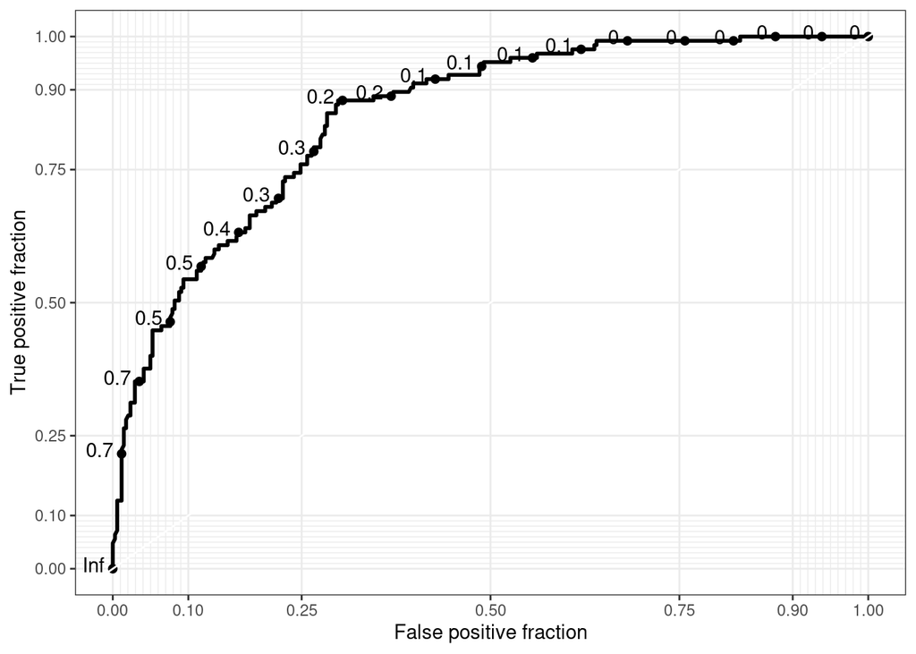

```r
ROC_plot
```

### Cross Validation:

This performs k-fold cross-validation on the `Returns` dataset, I initially encountered challenges with generating non-empty `perf_k` values in the vector, using the example code provided in class worksheets. To address this issue, I referred to external resources for guidance to generate the right AUC values. The article “How to Calculate AUC in R studio” from [GeeksforGeeks](https://www.geeksforgeeks.org/how-to-calculate-auc-area-under-curve-in-r/) provided a comprehensive step-by-step documentation on implementing the “pROC” library, which was essential for this analysis. To better the understand the roc object from the pROC library and accurately calculate the AUC for each iteration of k-fold cross-validation, I used Renesh Bedre’s blog post, Calculate AUC in R:Step-by-Step Guide With Example available at [Renesh Bedre’s blog](https://reneshbedre.com/blog/calculate-auc-in-r.html). These insights were crucial in effectively utilizing the for-loop and setup code from our class’s Worksheet 18 on cross-validation for a classification model.

```r
#install.packages("pROC")
library(pROC)
set.seed(123)
data <- returns[sample(nrow(returns)), ]

# Create indices for k folds
k <- 5
folds <- cut(seq(1, nrow(data)), breaks = k, labels = FALSE)

# Initialize a vector to keep track of the performance for each k-fold
perf_k <- numeric(k)

# Use a for-loop to get performance for each k-fold
for(i in 1:k){
  # Split data into train and test data
  train_not_i <- data[folds != i, ] # train data = all observations except in fold i
  test_i <- data[folds == i, ]  # test data = observations in fold i

  # Train model on train data (all but fold i)
  train_model <- glm(HighRisk ~ PriorHousing + `Specific Demographic` + `Fiscal Year`,
                     data = train_not_i,
                     family = "binomial")

  # Predict on test data
  predictions <- predict(train_model, newdata = test_i, type = "response")

  # Calculate ROC and AUC
  roc_obj <- roc(test_i$HighRisk, predictions)
  perf_k[i] <- auc(roc_obj)
}

# Performance for each fold
perf_k
```

```
## [1] 0.8037330 0.7623288 0.8458668 0.7958824 0.8509199
```

```r
# find the average of the perf_k values
mean(perf_k)
```

```
## [1] 0.8117462
```

## Decision Tree

### Fitting the Model

Fit a decision tree model to the `returns` dataset with `PriorHousing` and `Specific Demographic` as the predictiors for `Rate` (return rate). Create a visualization of the decision tree model.

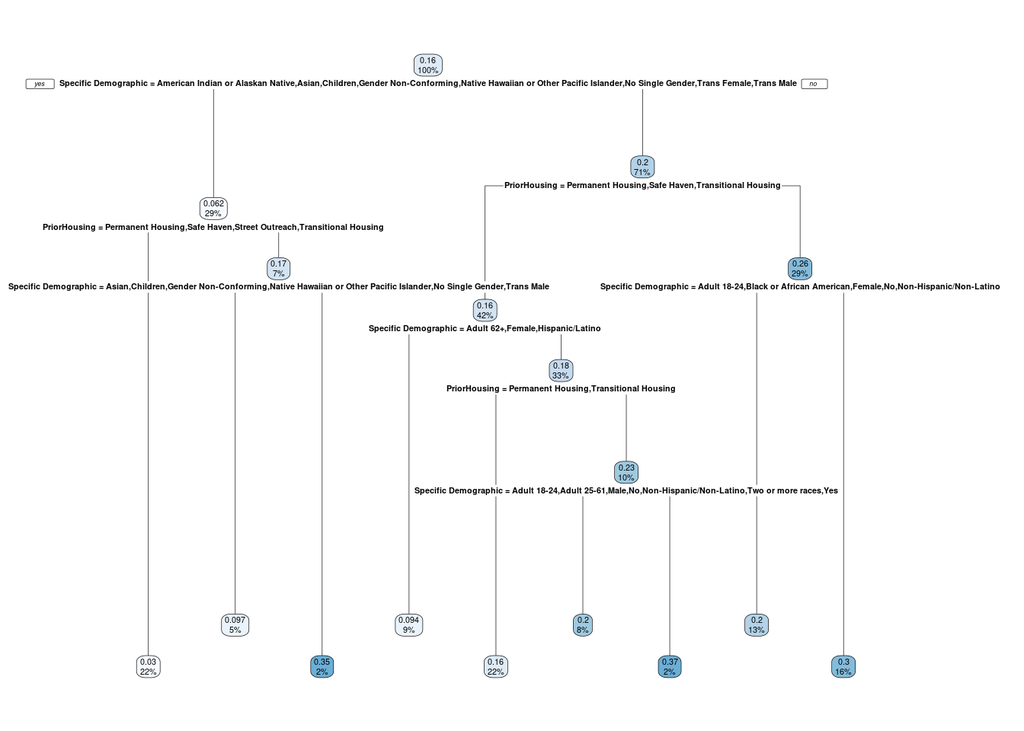

```r
#Consider the decision tree model
fit_tree_return <- rpart(Rate ~ PriorHousing + `Specific Demographic`,
                    data = returns)

# Visualize the decision tree
rpart.plot(fit_tree_return)
```

Evaluate the performance of the decision tree model.

```r
# Evaluate performance with RMSE
sqrt(mean((returns$Rate - predict(fit_tree_return, returns))^2))
```

```
## [1] 0.1454871
```

### Cross-validation

Perform a 5-fold cross-validation with the decision tree model. Calculate and report the average performance of the decision tree model across the 5 folds.

```r
# Choose number of folds
k = 5

# Randomly shuffle the data
set.seed(123)
# Randomly order rows in the dataset
data <- returns[sample(nrow(returns)), ]

# Create k folds from the dataset
folds <- cut(seq(1:nrow(data)), breaks = k, labels = FALSE)

# Initialize a vector to keep track of the performance for each k-fold
perf_k <- NULL

# Use a for-loop to get performance for each k-fold
for(i in 1:k){
  # Split data into train and test data
  train_not_i2 <- data[folds != i, ] # train data = all observations except in fold i
  test_i2 <- data[folds == i, ]  # test data = observations in fold i

  # Train model on train data (all but fold i)
  train_model <- rpart(Rate ~ PriorHousing +`Specific Demographic`,
                    data = train_not_i2)

  # Performance listed for each test data = fold i
  perf_k[i] <- sqrt(mean((
    test_i2$Rate - predict(train_model, newdata = test_i2))^2,
    na.rm = TRUE))
}

# Average performance over all k folds and variation
mean(perf_k)
```

```
## [1] 0.1652422
```

```r
sd(perf_k)
```

```
## [1] 0.0320852
```

```r
# Performance for each fold
perf_k
```

```
## [1] 0.1482440 0.2103537 0.1285738 0.1551550 0.1838845
```

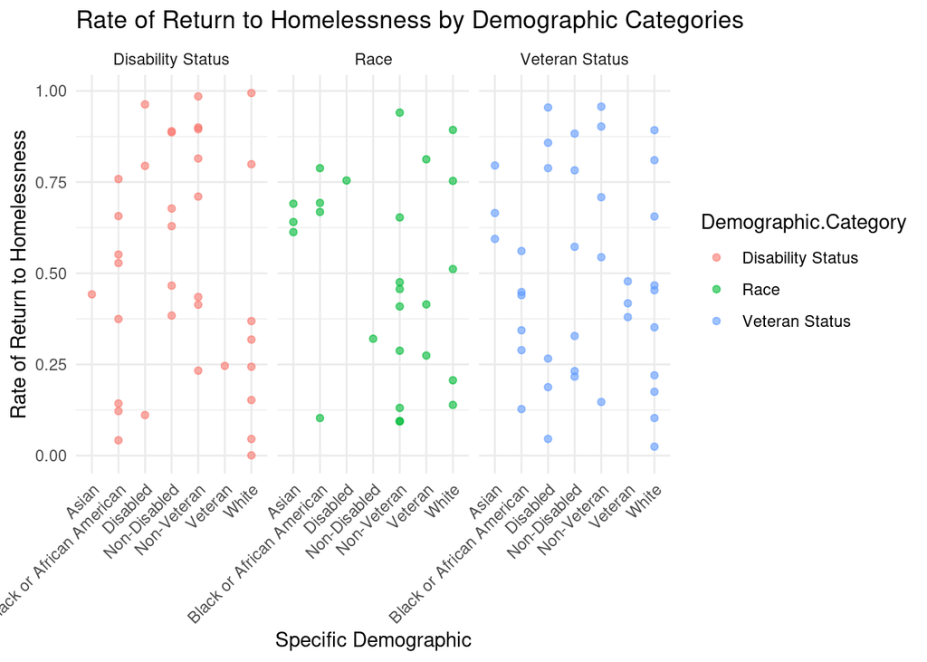

```r
library(ggplot2)
library(dplyr)

# Sample data creation for demonstration purposes (replace this with your actual data)
set.seed(123)  # for reproducibility
returns <- data.frame(
  Rate = runif(100, 0, 1),  # Replace with actual rate data
  `Demographic Category` = sample(c('Race', 'Veteran Status', 'Disability Status'), 100, replace = TRUE),
  `Specific Demographic` = sample(c('White', 'Black or African American', 'Asian', 'Veteran', 'Non-Veteran', 'Disabled', 'Non-Disabled'), 100, replace = TRUE)
)

# Filter for specific demographic categories of interest
filtered_data <- returns %>%
  filter(`Demographic.Category` %in% c('Race', 'Veteran Status', 'Disability Status'))


ggplot(filtered_data, aes(x = `Specific.Demographic`, y = Rate)) +
  geom_point(aes(color = `Demographic.Category`), alpha = 0.6) +
  facet_wrap(~ `Demographic.Category`) +
  theme_minimal() +
  theme(axis.text.x = element_text(angle = 45, hjust = 1)) +
  labs(title = 'Rate of Return to Homelessness by Demographic Categories',
       x = 'Specific Demographic', y = 'Rate of Return to Homelessness')
```

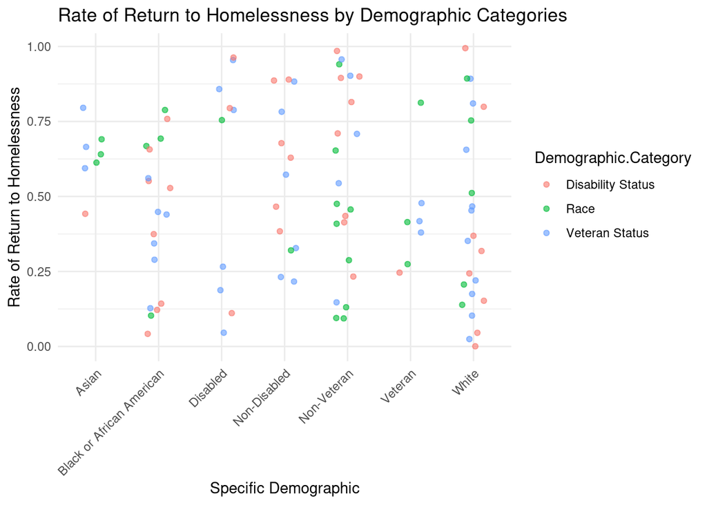

```r
ggplot(filtered_data, aes(x = `Specific.Demographic`, y = Rate, color = `Demographic.Category`)) +
  geom_jitter(alpha = 0.6, width = 0.2, height = 0) +
  theme_minimal() +
  theme(axis.text.x = element_text(angle = 45, hjust = 1)) +
  labs(title = 'Rate of Return to Homelessness by Demographic Categories',
       x = 'Specific Demographic', y = 'Rate of Return to Homelessness')
```

[figure not shown]

```r
# Visualize the decision tree for regression
rpart.plot(fit_tree_return,
           type = 0,  # Sets the type of plot
           extra = 1,  # Displays the number of observations in the node
           under = TRUE,  # Plots the number of observations under the branch
           cex = 0.6,  # Character expansion size for text
           tweak = 1.2  # Tweaks the size of the nodes relative to the default
           )  # Color nodes based on the fall prediction
```

# Discussion

There are some ethical issues that arose in our explanatory analysis. Certain demographics, such as “Two or More Races” do not have exit or return rates recorded for some or most fiscal years. Additionally, there is not an equal total number of subjects for each demographic, and there are confounding variables (mental health, resources, etc..) that differ from case to case. Regarding the original dataset from the City of Austin, the coding for `Demographic Category` and `Specific Demographic` are inconsistent (multiple spellings for the same variable), which we recoded and renamed for the purposes of our project.

We expected to see veteran status to be more influential on a return to homelessness than other demographics. However, we also believed race would have a greater impact on these rates, but our results showed that disability status affected return rates more. These results bring to the forefront Austin’s available support for veterans and the disabled. It would be interesting to continue analyzing the specific reasons why veterans and those with disabilities returned to homelessness. Was it a lack of effective city-funded programs? Was it health issues that made it harder to become self-sustaining? These could be questions that we would further look into to expand our research and analysis.

# References and Acknowledgements

**We extend our thanks to the City of Austin and the individuals involved in the open data that we utilized in this exploratory project. To our professor, Dr. Guyot, we appreciate your organizing this collaboration as well as your assistance during the data cleaning. Through this exploratory data analysis, we have learned to better organize our R code in a manner that would be easy to understand for someone who didn’t write the code. In addition, we have also learned the value of feedback from teammates to create the best and most concise end result. After this project, we are eager to wrangle and analyze more real-world data sets.**

##### Data sets Referenced:

- **Returns :** Texas, A. (2020, March 2). Strategic Measure_Number of returns to homelessness. Austintexas.gov. https://data.austintexas.gov/Health-and-Community-Services/Strategic-Measure_Number-of-returns-to-homelessnes/jy3f-9rpf

##### Websites Referenced:

- **GeeksforGeeks: How to Calculate AUC (Area Under Curve) in R** (n.d.). How to Calculate AUC (Area Under Curve) in R? GeeksforGeeks.com. https://www.geeksforgeeks.org/how-to-calculate-auc-area-under-curve-in-r/
- **RS Blog:Calculate AUC in R:** Bedre,Renesh. (2021, April 7). Calculate AUC in R: Step-by-Step Guide with Example. R Studio Blog.https://www.reneshbedre.com/blog/calculate-auc-in-r.html